# Week 2 - Regression analysis

This week I studied doing regression analysis with R in the IODS-course. Regression analysis is a method for estimating relationships between variables. In this exercise, we will look at the connection of learning strategies and attitude to the course points of one statistics course

More detailed description of the dataset can be found from http://www.helsinki.fi/~kvehkala/JYTmooc/JYTOPKYS2-meta.txt

lets read the data from the disk

```r
learning2014 <- read.table(file= 'data/learning2014.txt', header=T)
```

Dimensions and structure of the data

```r
dim(learning2014)
```

```
## [1] 166   7
```

There are 166 observations and 7 variables in the data

```r
str(learning2014)
```

```
## 'data.frame':    166 obs. of  7 variables:
##  $ gender  : Factor w/ 2 levels "F","M": 1 2 1 2 2 1 2 1 2 1 ...
##  $ Age     : int  53 55 49 53 49 38 50 37 37 42 ...
##  $ attitude: num  3.7 3.1 2.5 3.5 3.7 3.8 3.5 2.9 3.8 2.1 ...
##  $ deep    : num  3.75 2.88 3.88 3.5 3.75 ...
##  $ stra    : num  3.38 2.75 3.62 3.12 3.62 ...
##  $ surf    : num  2.58 3.17 2.25 2.25 2.83 ...
##  $ Points  : int  25 12 24 10 22 21 21 31 24 26 ...
```

The 7 variables in the dataframe are gender, Age, attitude, deep, stra, surf and Points

Lets check the summary and visualize the data

If not already installed, you should run the command install.packages(c(“ggplot2”,“GGally”)) to install required packages for data visualization

The summaries of the variables

```r
summary(learning2014)
```

```
##  gender       Age           attitude          deep            stra
##  F:110   Min.   :17.00   Min.   :1.400   Min.   :1.625   Min.   :1.250
##  M: 56   1st Qu.:21.00   1st Qu.:2.600   1st Qu.:3.500   1st Qu.:2.625
##          Median :22.00   Median :3.200   Median :3.875   Median :3.188
##          Mean   :25.51   Mean   :3.143   Mean   :3.796   Mean   :3.121
##          3rd Qu.:27.00   3rd Qu.:3.700   3rd Qu.:4.250   3rd Qu.:3.625
##          Max.   :55.00   Max.   :5.000   Max.   :4.875   Max.   :5.000
##       surf           Points
##  Min.   :1.583   Min.   : 7.00
##  1st Qu.:2.417   1st Qu.:19.00
##  Median :2.833   Median :23.00
##  Mean   :2.787   Mean   :22.72
##  3rd Qu.:3.167   3rd Qu.:27.75
##  Max.   :4.333   Max.   :33.00
```

Access the GGally and ggplot2 libraries

```r
library(GGally)
```

```r
library(ggplot2)
```

draw a scatter plot matrix of the variables in learning2014. [-1] excludes the first column (gender)

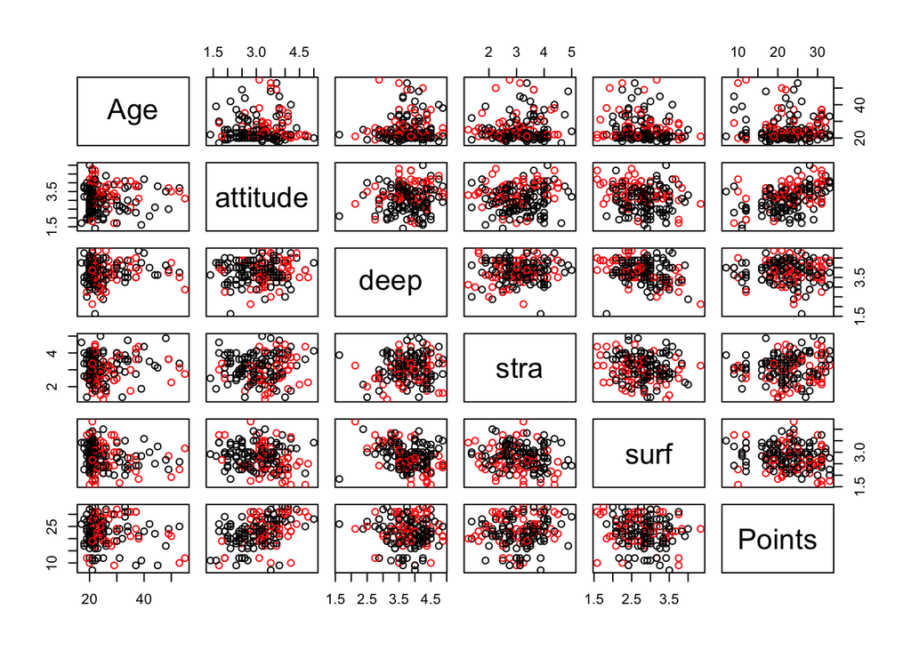

```r
pairs(learning2014[-1], col=learning2014$gender)
```

create a more advanced plot matrix with ggpairs()

```r
p <- ggpairs(learning2014, mapping = aes(col=gender, alpha = 0.3), lower = list(combo = wrap("facethist", bins = 20)))
```

draw the plot

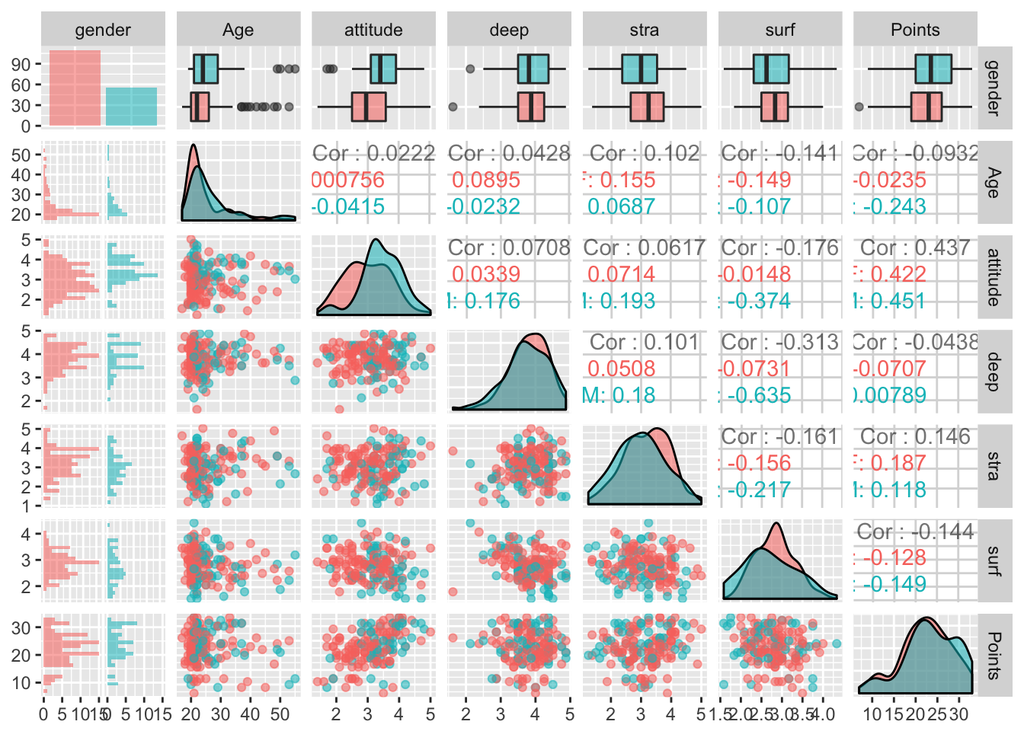

```r
p
```

It looks like Points is correlated most heavily with attitude, stra and surf. We will use these variables later in our regression model. Students tend to be fairly young and there is more females than males, which is not that suprising - these are university students, after all. Deep learning has its peak on the higher scores.

Next, we should build a model with the variables described above.

Lets create a regression model with attitude, stra and surf as explanatary variables, Points to be explained and print a summary of it

```r
r_model <- lm(Points ~ attitude + stra + surf, data = learning2014)
```

```r
summary(r_model)
```

```
##
## Call:
## lm(formula = Points ~ attitude + stra + surf, data = learning2014)
##
## Residuals:
##      Min       1Q   Median       3Q      Max
## -17.1550  -3.4346   0.5156   3.6401  10.8952
##
## Coefficients:
##             Estimate Std. Error t value Pr(>|t|)
## (Intercept)  11.0171     3.6837   2.991  0.00322 **
## attitude      3.3952     0.5741   5.913 1.93e-08 ***
## stra          0.8531     0.5416   1.575  0.11716
## surf         -0.5861     0.8014  -0.731  0.46563
## ---
## Signif. codes:  0 '***' 0.001 '**' 0.01 '*' 0.05 '.' 0.1 ' ' 1
##
## Residual standard error: 5.296 on 162 degrees of freedom
## Multiple R-squared:  0.2074, Adjusted R-squared:  0.1927
## F-statistic: 14.13 on 3 and 162 DF,  p-value: 3.156e-08
```

As a final touch, lets see graphical analysis of the results by plotting Residuals vs Fitted values, Normal QQ-plot and Residuals vs Leverage

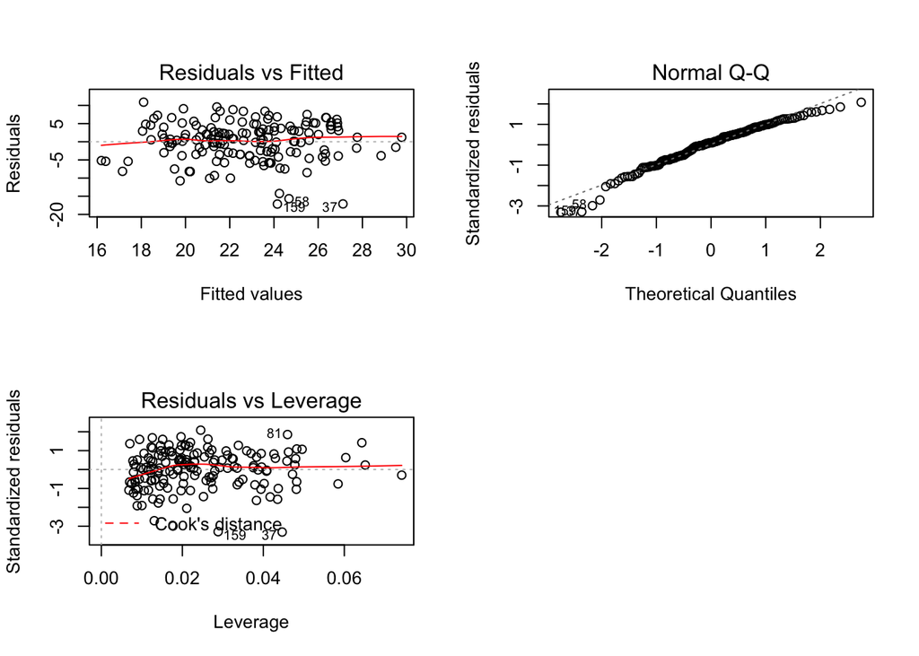

```r
par(mfrow=c(2,2))
plot(r_model, which= c(1,2,5))
```

Residuals vs Fitted seems to be fairly random, so the errors should not depend on explanatory variables Q-Q plot seems such that the errors of the model seem fairly normally distributed. There is some deviation in the beginning and the end, but it does not seem dramatic. Residuals vs Residuals plot shows some outliers, but their leverage is not drastically high compared to other datapoints.